# Estudios de Informática, Multimedia y Telecomunicaciones

### 4.2.1 Pruebas de normalidad para CCAA

```r
# Prueba de Shapiro-Wilk para AN
shapiro.test(AN[,3])
```

```
##
##  Shapiro-Wilk normality test
##
## data:  AN[, 3]
## W = 0.8058, p-value = 2.073e-09
```

```r
# Prueba de Shapiro-Wilk para CB
shapiro.test(CB[,3])
```

```
##
##  Shapiro-Wilk normality test
##
## data:  CB[, 3]
## W = 0.80977, p-value = 2.728e-09
```

```r
# Prueba de Shapiro-Wilk para CM
shapiro.test(CM[,3])
```

```
##
##  Shapiro-Wilk normality test
##
## data:  CM[, 3]
## W = 0.78876, p-value = 6.662e-10
```

Vemos como en los tres casos el p_value obtenido está por debajo del nivel de significancia fijado ($\alpha=0.05$). Rechazamos H0, las muestras no responden a una distribución normal.

Historigramas presentados a continuación, confirmando que los datos no siguen una distribución normal.

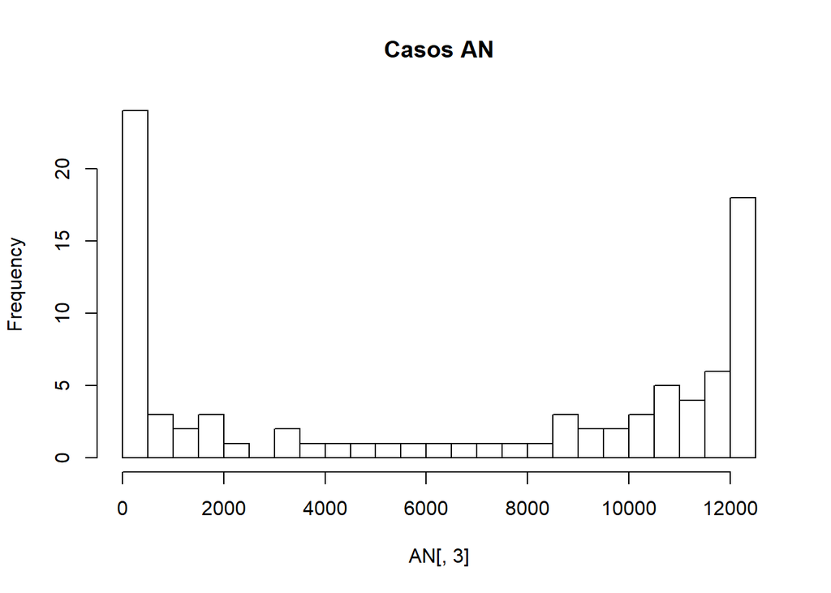

```r
#Histogramas COVID
hist(AN[,3],breaks=20,main="Casos AN")
```

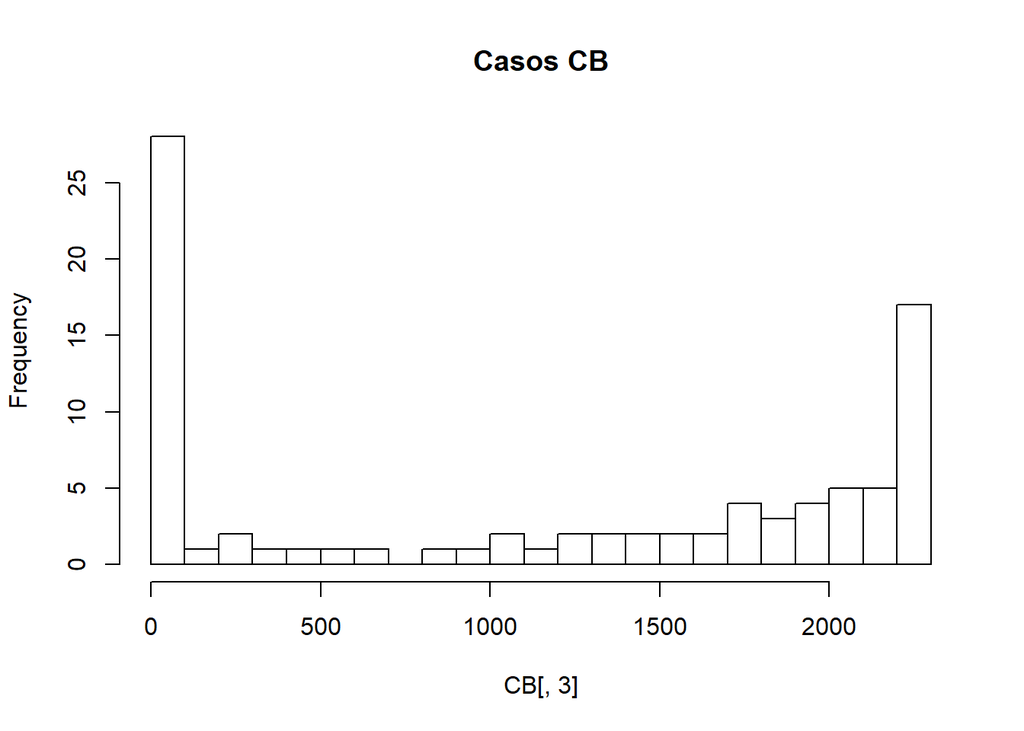

```r
hist(CB[,3],breaks=20,main="Casos CB")
```

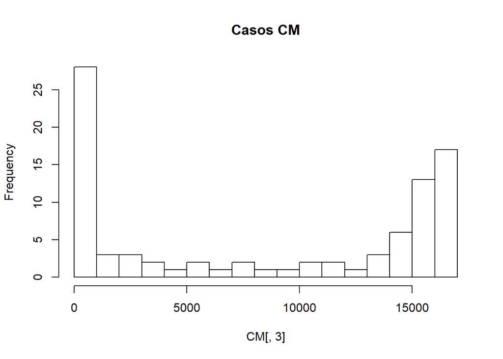

```r
hist(CM[,3],breaks=20,main="Casos CM")
```

### 4.2.2 Pruebas de normalidad para evolución demanda eléctrica

```r
# Prueba de Shapiro-Wilk para AN
shapiro.test(elect_2019[,2])
```

```
##
##  Shapiro-Wilk normality test
##
## data:  elect_2019[, 2]
## W = 0.97301, p-value = 0.01624
```

```r
# Prueba de Shapiro-Wilk para AN
shapiro.test(elect_2020[,2])
```

```
##
##  Shapiro-Wilk normality test
##
## data:  elect_2020[, 2]
## W = 0.96494, p-value = 0.003058
```

Historigramas presentados a continuación para ambos sets de datos (2019 y 2020):

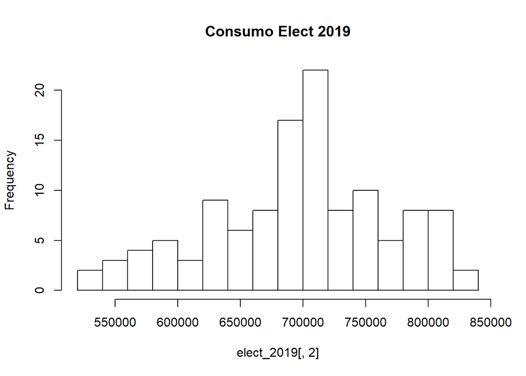

```r
hist(elect_2019[,2],breaks=20,main="Consumo Elect 2019")
```

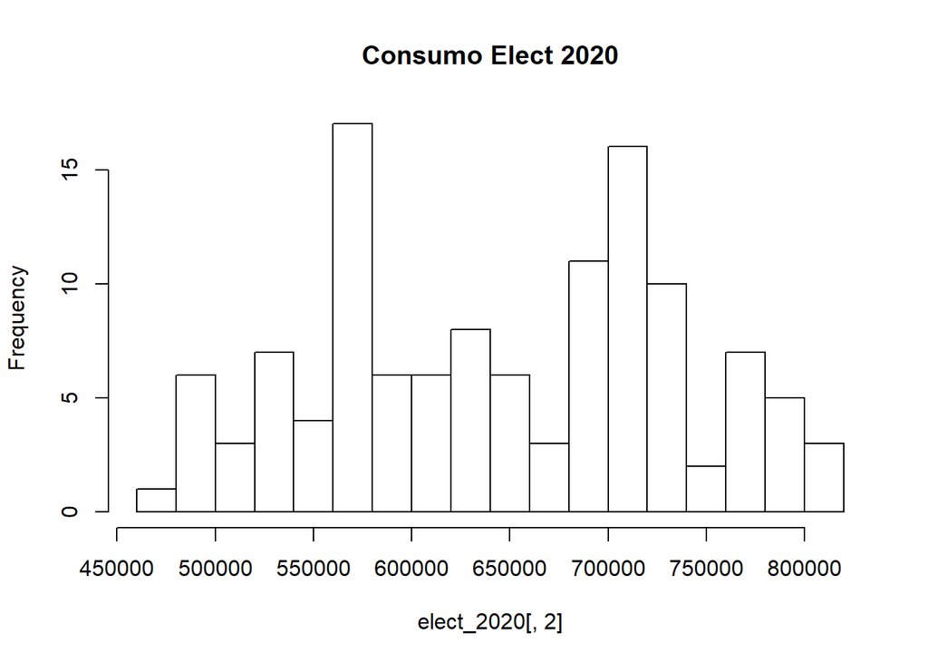

```r
hist(elect_2020[,2],breaks=20,main="Consumo Elect 2020")
```

## 4.3 Pruebas Estadísticas

El planteamiento de pruebas estadísticas con los dataframes considerados en la práctica, a consideración de los alumnos, es ciertamente un poco limitado. El conjunto de datos está posiblemente más orientado al desarrollo de comparativas gráficas como las mostradas en el apartado 5 y al desarrollo de contraste de hipótesis. Es en este segundo punto en el que se ha centrado el presente apartado, en el planteamiento de un contraste de hipótesis sobre la media, a fin de concluir si la media de consumo eléctrico es mayor en año 2019 que en año 2020. Objetivo.

Este contraste de hipótesis se construirá como un test unilateral, en el que los resultados válidos se sitúan a un lado de la igualdad para la hipótesis alternativa, con un contraste de dos muestras.

$$\left\{
\begin{array}{ll}
H_{0}: & \mu_{2019}=\mu_{2020} \\
H_{1}: & \mu_{2019} >\mu_{2020}
\end{array}
\right.$$
Se plantea una resolución mediante el contraste de hipótisis con una fiabilidad de no rechazo de la hipótesis nula del 95% de nivel de confianza (alpha=0.05).

Vimos ya en el apartado anterior como los datos para el año 2020 no siguen exactamente una distribución normal. En este punto, haremos uso del Teorema del Límite Central, la distribución cuenta con un número suficientemente grande de muestras (n>30), para asumir que la media si responde a una distribución normal.

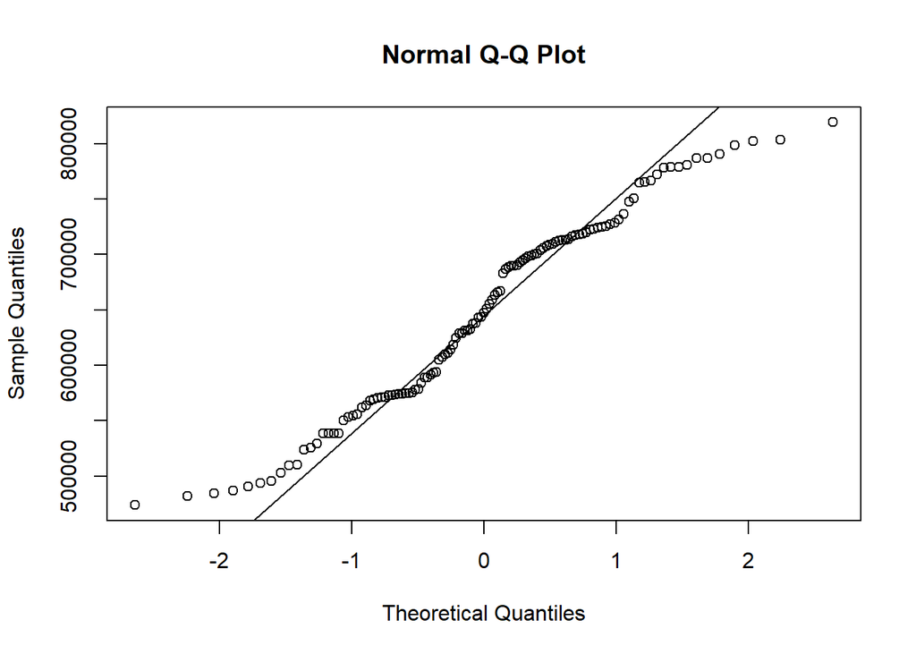

```r
qqnorm(elect_2020$ev_demanda)
qqline(elect_2020$ev_demanda)
```

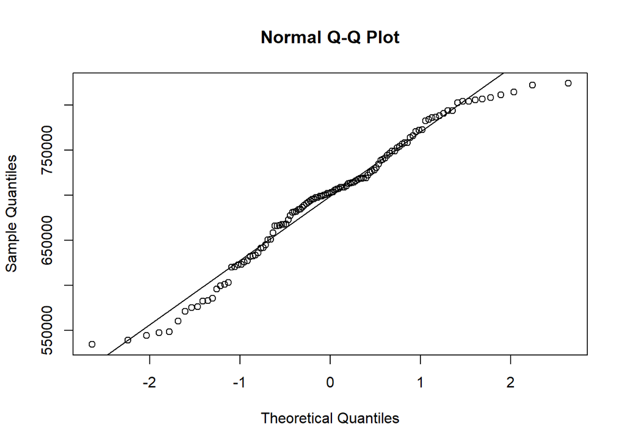

```r
qqnorm(elect_2019$ev_demanda)
qqline(elect_2019$ev_demanda)
```

Procedemos al cálculo del estadístico para el contraste de hipótesis sobre la media propuesto. Utilizaremos la función “myttest”, tomada como referencia de la asignatura “Estadística Avanzada” de la UOC.

```r
myttest <- function( x1, x2, CL=0.95,equalvar=TRUE, alternative="bilateral" ){
#z test
mean1<-mean(x1)
n1<-length(x1)
sd1<-sd(x1)
mean2<-mean(x2)
n2<-length(x2)
sd2<-sd(x2)
if (equalvar==TRUE){
  s <-sqrt( ((n1-1)*sd1^2 + (n2-1)*sd2^2 )/(n1+n2-2) )
  Sb <- s*sqrt(1/n1 + 1/n2)
  df<-n1+n2-2
}
else{ #equalvar==FALSE
  Sb <- sqrt( sd1^2/n1 + sd2^2/n2 )
  denom <- ( (sd1^2/n1)^2/(n1-1) +(sd2^2/n2)^2/(n2-2))
  df <- ((sd1^2/n1 + sd2^2/n2)^2) / denom
}
alfa <- (1-CL)
t<- (mean1-mean2) / Sb
if (alternative=="bilateral"){
  tcritical <- qnorm( alfa/2, lower.tail=FALSE ) #two sided
  pvalue<-pnorm( abs(t), lower.tail=FALSE )*2 #two sided
}
else if (alternative=="less"){
  tcritical <- qnorm( alfa, df, lower.tail=TRUE )
  pvalue<-pnorm( t, df, lower.tail=TRUE )
}
else{ #(alternative=="greater")
  tcritical <- qnorm( alfa, lower.tail=FALSE )
  pvalue<-pnorm( t, lower.tail=FALSE )
}
#Guardamos en resultado en un data frame
  info<-data.frame(t,tcritical,pvalue)
  info %>% kable() %>% kable_styling()
  return (info)
}
```

```r
info<-myttest( elect_2019$ev_demanda, elect_2020$ev_demanda, alternative="greater" )
```

# 5 Representación de los resultados

**Evolución demanda 2019-2020 (enero-febrero-marzo-abril)**

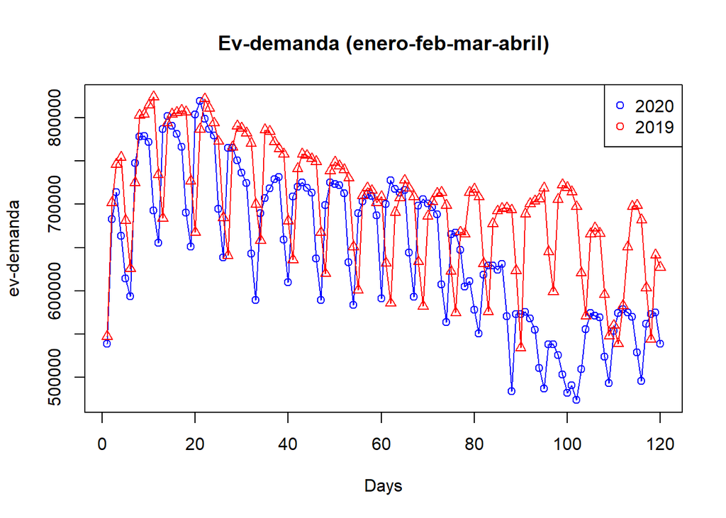

```r
plot(elect$ev_demanda_2020, type="overplotted",   pch=1, col="blue", xlab="Days",    ylab="ev-demanda",   main="Ev-demanda (enero-feb-mar-abril)", ylim=c(min(elect$ev_demanda_2020), max(elect$ev_demanda2019)))
lines(elect$ev_demanda2019,type="overplotted",pch=2,col="red")
legend("topright",legend=c("2020","2019"),    pch=c(1,1),col=c("blue","red"))
```

```r
#particionamos el dataframe para el posterior tratamiento de los resultados por mes.
elect_jan=elect[elect$month==1,]
elect_feb=elect[elect$month==2,]
elect_mar=elect[elect$month==3,]
elect_apr=elect[elect$month==4,]
```

**Evolución demanda 2019-2020 (Enero)**

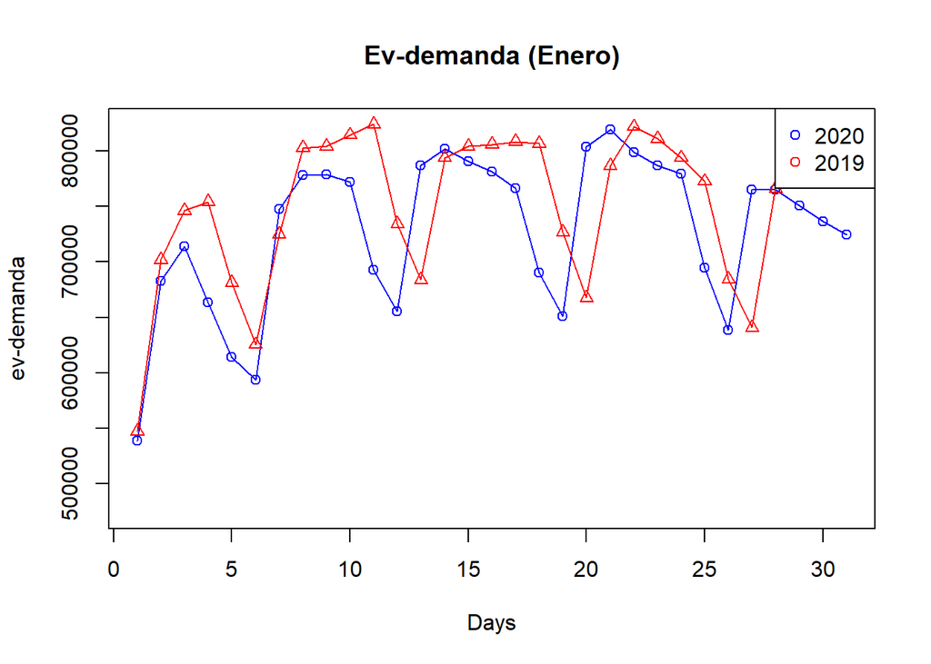

```r
plot(elect_jan$day, elect_jan$ev_demanda_2020, type="overplotted",   pch=1, col="blue", xlab="Days",    ylab="ev-demanda",   main="Ev-demanda (Enero)", ylim=c(min(elect$ev_demanda_2020), max(elect$ev_demanda2019)))
lines(elect_jan$day, elect_jan$ev_demanda2019,type="overplotted",pch=2,col="red")
legend("topright",legend=c("2020","2019"),    pch=c(1,1),col=c("blue","red"))
```

**Evolución demanda 2019-2020 (Febrero)**

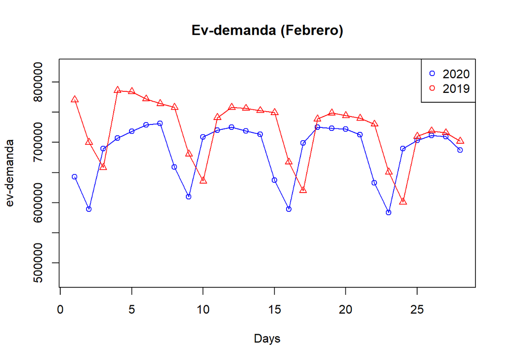

```r
plot(elect_feb$day, elect_feb$ev_demanda_2020, type="overplotted",   pch=1, col="blue", xlab="Days",    ylab="ev-demanda",   main="Ev-demanda (Febrero)", ylim=c(min(elect$ev_demanda_2020), max(elect$ev_demanda2019)))
lines(elect_feb$day, elect_feb$ev_demanda2019,type="overplotted",pch=2,col="red")
legend("topright",legend=c("2020","2019"),    pch=c(1,1),col=c("blue","red"))
```

**Evolución demanda 2019-2020 (Marzo)**

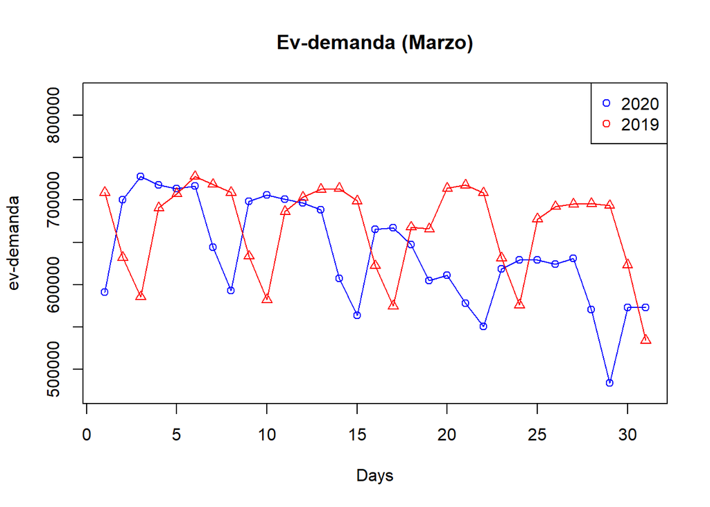

```r
plot(elect_mar$day, elect_mar$ev_demanda_2020, type="overplotted",   pch=1, col="blue", xlab="Days",    ylab="ev-demanda",   main="Ev-demanda (Marzo)", ylim=c(min(elect$ev_demanda_2020), max(elect$ev_demanda2019)))
lines(elect_mar$day, elect_mar$ev_demanda2019,type="overplotted",pch=2,col="red")
legend("topright",legend=c("2020","2019"),    pch=c(1,1),col=c("blue","red"))
```

**Evolución demanda 2019-2020 (Abril)**

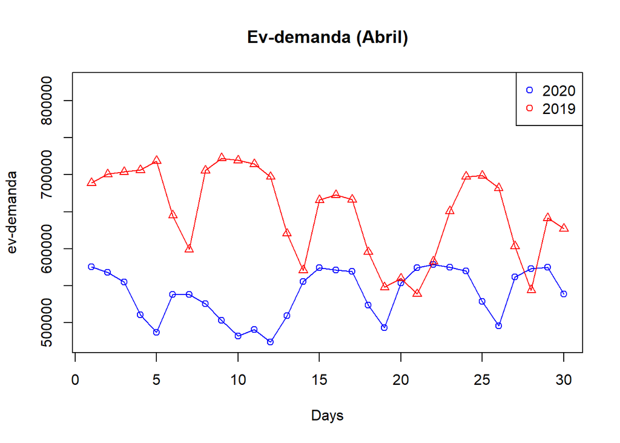

```r
plot(elect_apr$day, elect_apr$ev_demanda_2020, type="overplotted",   pch=1, col="blue", xlab="Days",    ylab="ev-demanda",   main="Ev-demanda (Abril)", ylim=c(min(elect$ev_demanda_2020), max(elect$ev_demanda2019)))
lines(elect_apr$day, elect_apr$ev_demanda2019,type="overplotted",pch=2,col="red")
legend("topright",legend=c("2020","2019"),    pch=c(1,1),col=c("blue","red"))
```

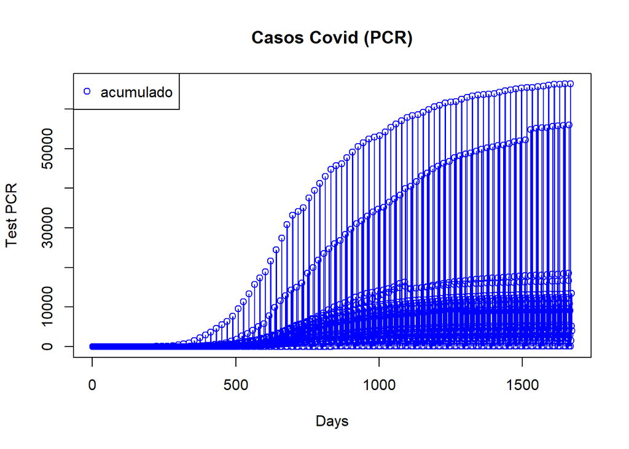

```r
plot(covid_espana$PCR., type="overplotted",   pch=1, col="blue", xlab="Days",    ylab="Test PCR",   main="Casos Covid (PCR)", ylim=c(min(covid_espana$PCR), max(covid_espana$PCR)))
legend("topleft",legend="acumulado",    pch=c(1,2),col=c("blue"))
```

**Evolución Covid - Acumulado**

Representación de los resultados para un mejor entendimiento de los datos, limitado a Comunidad de MAdrid (MD), Cataluña (CT) y País Vasco (PV).

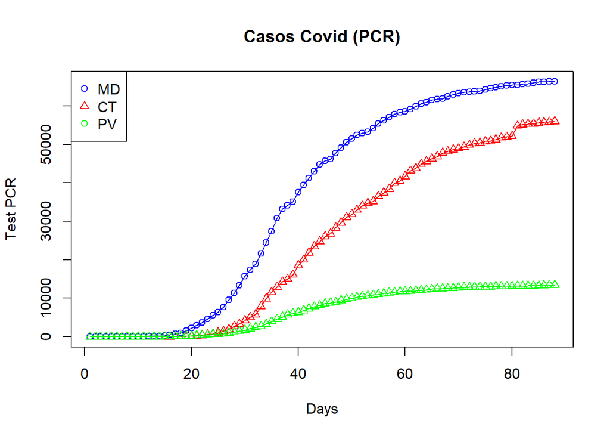

```r
plot(covid_espana$PCR.[CCAA=="MD"], type="overplotted",   pch=1, col="blue", xlab="Days",    ylab="Test PCR",   main="Casos Covid (PCR)", ylim=c(min(covid_espana$PCR), max(covid_espana$PCR)))
lines(covid_espana$PCR.[CCAA=="CT"],type="overplotted",pch=2,col="red")
lines(covid_espana$PCR.[CCAA=="PV"],type="overplotted",pch=2,col="green")
legend("topleft",legend=c("MD","CT","PV"),    pch=c(1,2),col=c("blue","red","green"))
```

```r
#particionamos el dataframe para un posterior tratamiento de los resultados por mes
covid_espana_feb=covid_espana[covid_espana$month==2,]
covid_espana_mar=covid_espana[covid_espana$month==3,]
covid_espana_apr=covid_espana[covid_espana$month==4,]
covid_espana_may=covid_espana[covid_espana$month==5,]
```

# 6 6. Resolución del problema

En esta segunda práctica, orientada al entendimiento y análisis del impacto del Covid en el consumo energético, se ha acotado en mejor medida el estudio, con mayor volúmen de datos disponible (meses enero, febrero, marzo y abril).

En lo que respecta al pre-proceso de datos, resaltar la integración de actividades de pre-procesado de datos por dos vías diferentes, una primera parte a través de los scripts definidos en python para la generación de los dataframes (cubierto en la Práctica 1), complementándose posteriormente con un tratamiento de los los mismos en R, proceso detallado en la presente práctica (Práctica 2).

Concluido el postproceso de los datos, queda la pregunta de si realmente hemos sido capaces de proporcionar una respuesta al problema planteado: ¿Existe reducción en el consumo energíco como consecuencia del Covid19?. Podemos concluir en este punto que efectivamente la irrupción del virus en España ha tenido un impacto significativo en los resultados de consumo eléctrico, hecho sustentado en los siguientes puntos:

**Comparativa gráfica**

Volvemos en este punto a las comparativas gráficas presentadas en el apartado 5. Los consumos energéticos, para meses de enero y febrero, muestran tendencias muy similares, las cuales se mantienen incluso durante las primeras fases del mes de marzo. Sin embargo, es a finales de este mes, donde se muestra un descenso significativo del consumo energético, el cual se mantiene a lo largo del mes de abril.

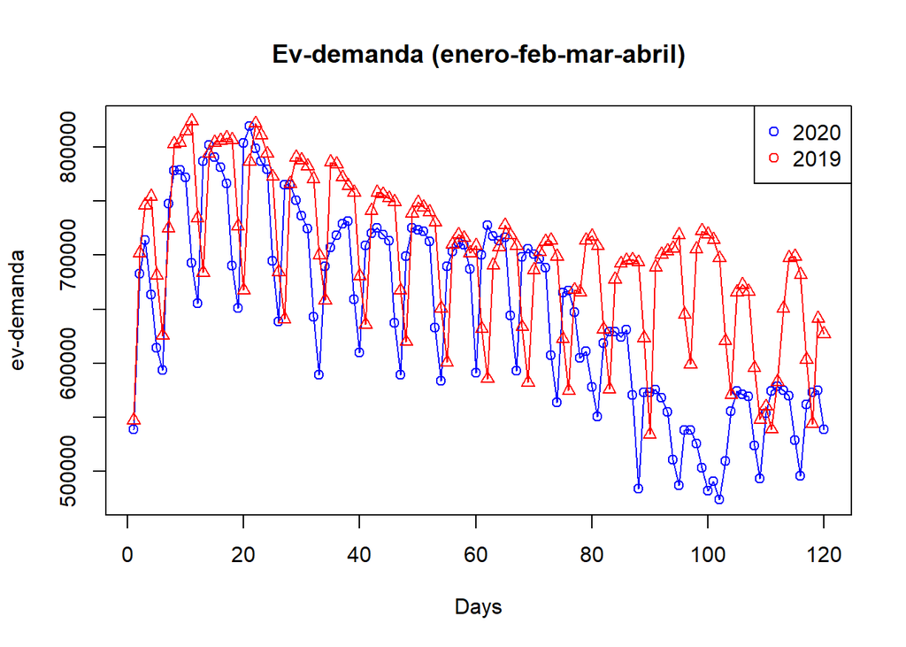

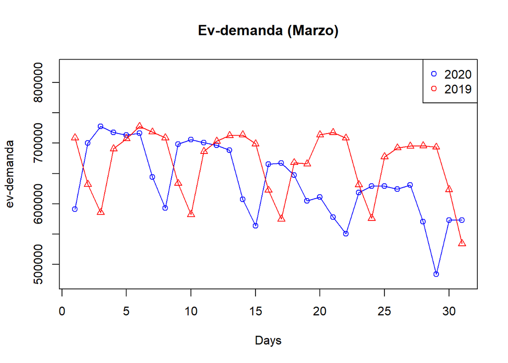

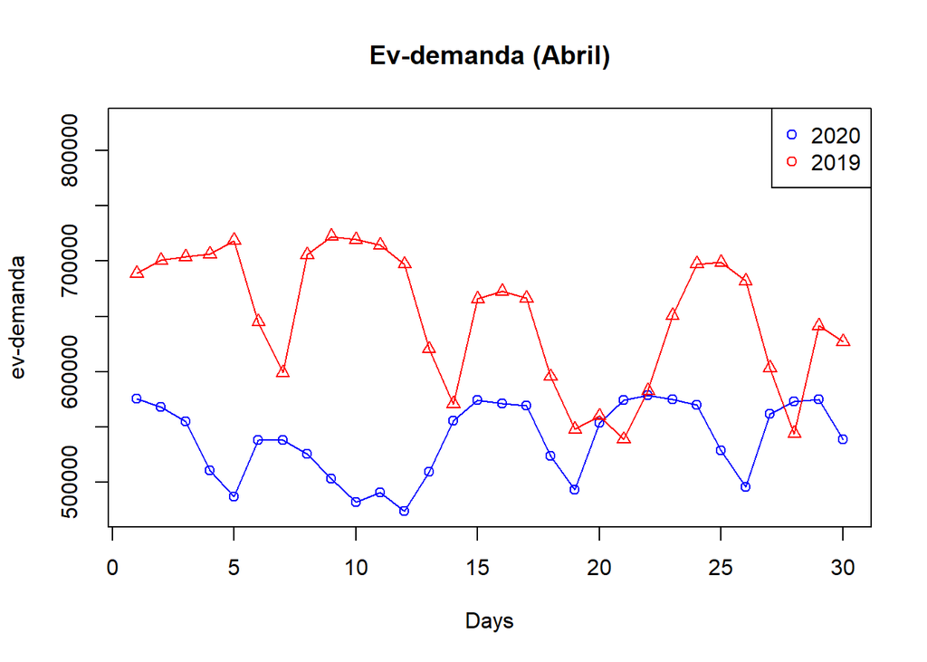

Cruzando estos datos con la evolución de casos registrados en España, vemos como el descenso en consumo energético correla bastante bien con el punto en que la curva de contagios comienza a tomar su máxima pendiente.

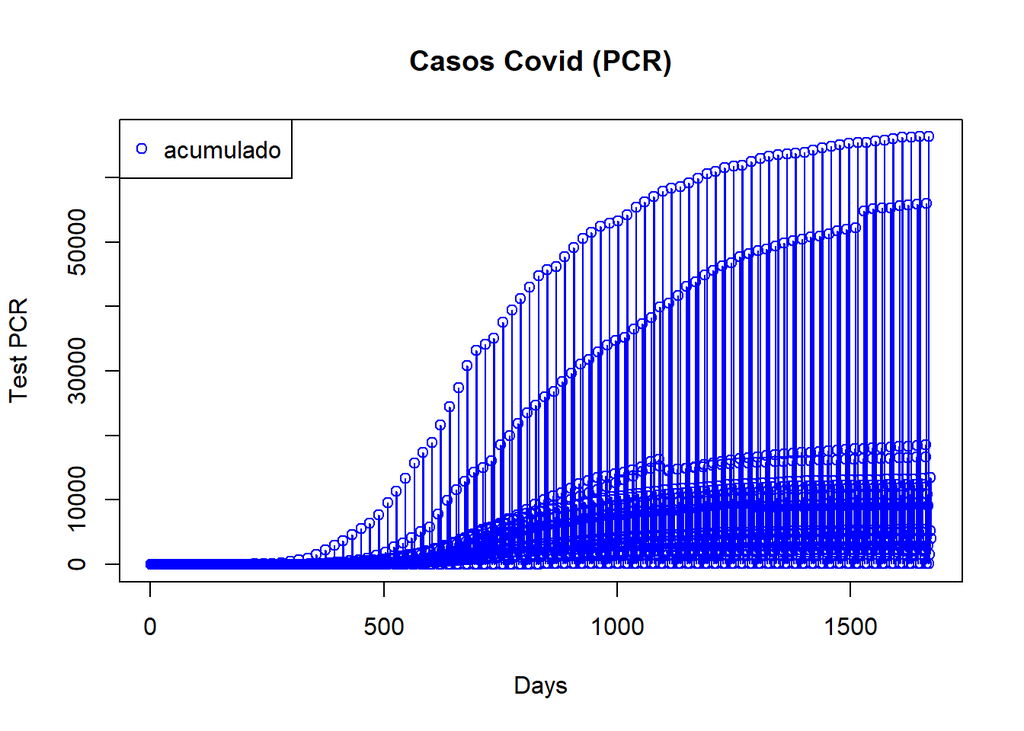

**Contraste de hipótesis**